# Practical 0

Alexandra Del Favero-Campbell

2024-05-09

```r
library(dplyr)
library(tidyverse)
library(datasauRus)
dino_data<-datasaurus_dozen %>%
  filter(dataset == "dino")
```

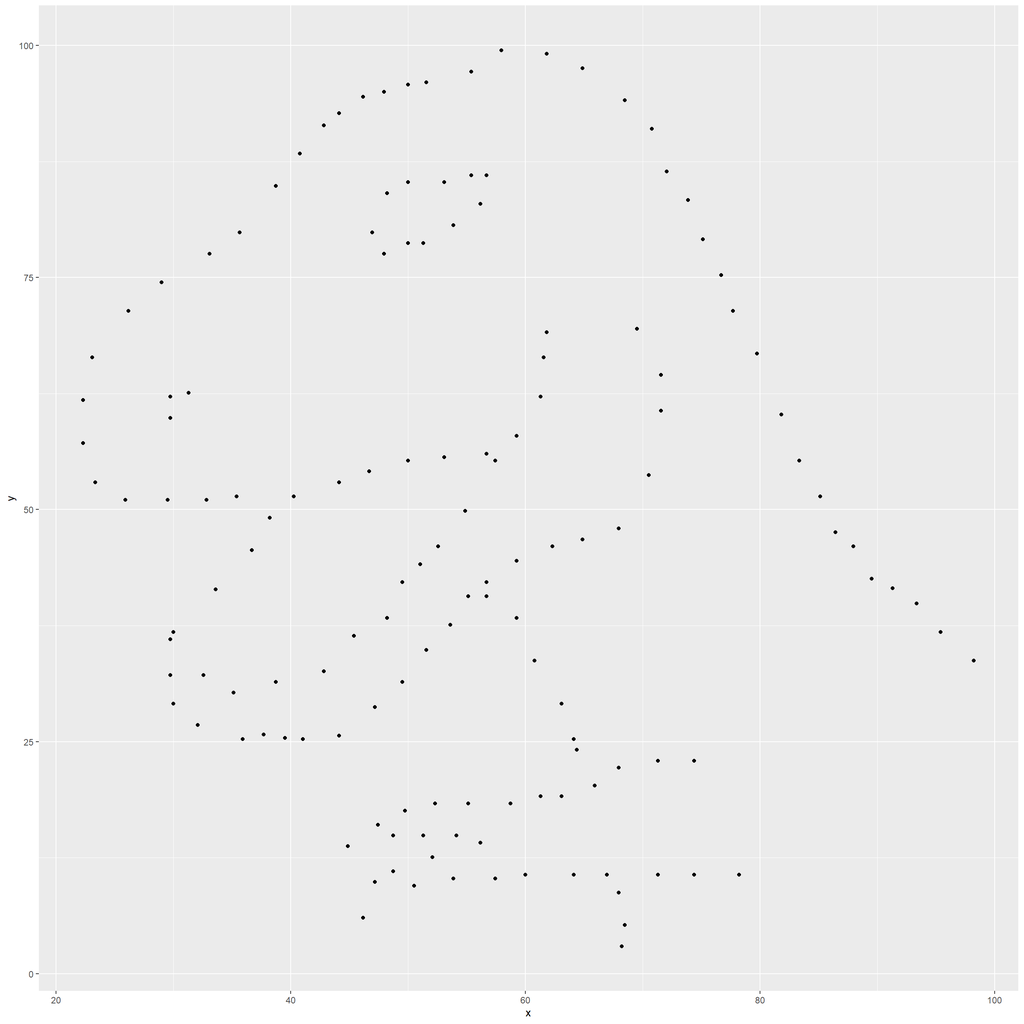

```r
ggplot(data=dino_data,mapping=aes(x=x,y=y))+geom_point()
```

Calculate the summary statistic (i.e., correlation coefficient) between x and y.

```r
dino_data %>%
  summarize(r=cor(x,y))
```

```
## # A tibble: 1 × 1
##         r
##     <dbl>
## 1 -0.0645
```

3. Plot y vs. x for the “star” dataset. Then, calculate the correlation coefficient between x and y for this dataset. How does this value compare to the r in “dino”?

```r
star_data<-datasaurus_dozen %>%
  filter(dataset=="star")
```

Plot x and y of star dataset

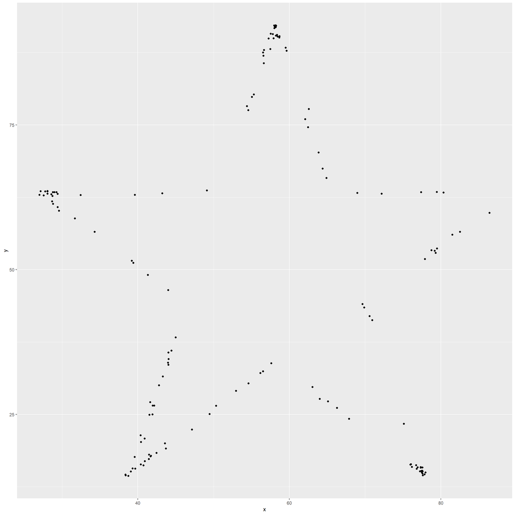

```r
ggplot(data=star_data,mapping=aes(x=x,y=y))+
  geom_point()
```

Calculate correlation coefficient of x and y from star dataset.

```r
star_data %>%
  summarize(r=cor(x,y))
```

```
## # A tibble: 1 × 1
##         r
##     <dbl>
## 1 -0.0630
```

Comparing both correlation coefficients, we see that both datasets have a quite low negative correlation coefficient between their respective x and y variables. However, the dino dataset has a bit of a minutely higher correlation compared to the star dataset.

4. Plot y vs. x for the “circle” dataset. Then, calculate the correlation coefficient between x and y for this dataset. How does this value compare to the r of dino?

A. Filter out our data so that we only are looking at the “circle” dataset.

```r
circle_data <- datasaurus_dozen %>%
  filter(dataset == "circle")
```

B. Plot visualization of x and y of “circle” dataset.

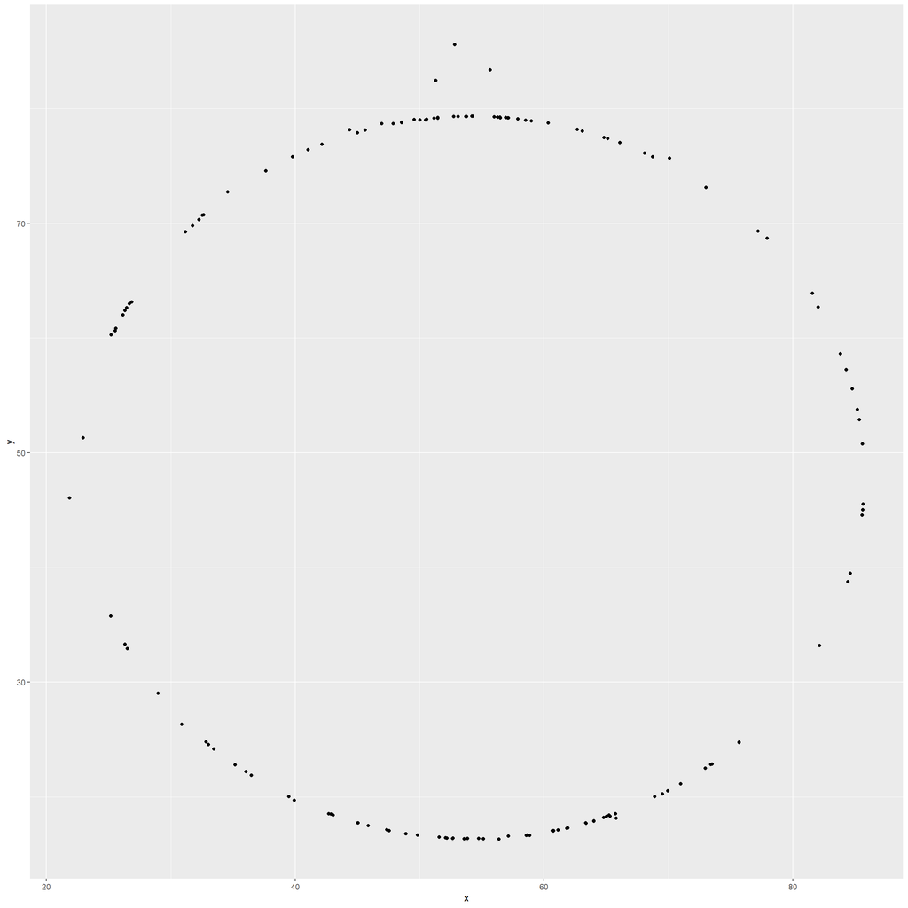

```r
ggplot(data = circle_data, mapping = aes(x = x, y = y)) +
  geom_point()
```

C. Calculate correlation coefficient (r) between x and y and compare it to the dino dataset.

```r
circle_data %>%
  summarize(r=cor(x,y))
```

```
## # A tibble: 1 × 1
##         r
##     <dbl>
## 1 -0.0683
```

```r
dino_data %>%
  summarize(r=cor(x,y))
```

```
## # A tibble: 1 × 1
##         r
##     <dbl>
## 1 -0.0645
```

Both of these correlation coefficients are quite low and both show a negative relationship. However, the circle dataset has a slightly higher correlation between x and y than the dino dataset does.

5. Plot all datasets at once. In order to do this we will make use of facetting.

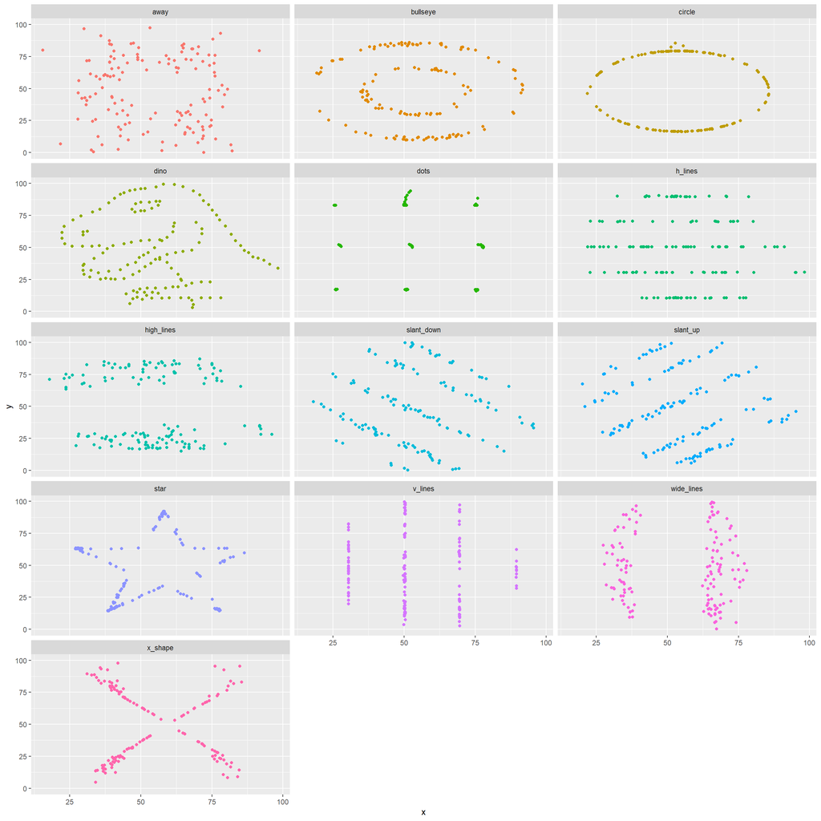

```r
ggplot(datasaurus_dozen,aes(x=x,y=y,color=dataset))+
  geom_point()+
  facet_wrap(~dataset,ncol=3)+
  theme(legend.position="none")
```

Now we will also use the group_by function to generate all of the correlation coefficients for these plots.

```r
datasaurus_dozen %>%
  group_by(dataset) %>%
             summarize(r=cor(x,y))
```

```
## # A tibble: 13 × 2
##    dataset          r
##    <chr>        <dbl>
##  1 away       -0.0641
##  2 bullseye   -0.0686
##  3 circle     -0.0683
##  4 dino       -0.0645
##  5 dots       -0.0603
##  6 h_lines    -0.0617
##  7 high_lines -0.0685
##  8 slant_down -0.0690
##  9 slant_up   -0.0686
## 10 star       -0.0630
## 11 v_lines    -0.0694
## 12 wide_lines -0.0666
## 13 x_shape    -0.0656
```